# Topic 7: Word Embeddings

Desik Somasundaram

Today we are using climbing incident data from this repo: https://github.com/ecaroom/climbing-accidents. Some analysis (in Excel) on the data was written up into a Rock and Ice magazine article.

But I’ve constructed our data set (link below) by pulling a few key variables including the full text of each incident report.

```r
incidents_df<-read_csv("https://raw.githubusercontent.com/MaRo406/EDS_231-text-sentiment/825b159b6da4c7040ce8295b9eae2fbbe9991ffd/dat/climbing_report_text.csv")
unigram_probs <- incidents_df %>%
    unnest_tokens(word, Text) %>%
    anti_join(stop_words, by = 'word') %>%
    count(word, sort = TRUE) %>%
    mutate(p = n / sum(n))
unigram_probs
```

```
## # A tibble: 25,205 × 3
##    word         n       p
##    <chr>    <int>   <dbl>
##  1 rope      5129 0.00922
##  2 feet      5101 0.00917
##  3 climbing  4755 0.00855
##  4 route     4357 0.00783
##  5 climbers  3611 0.00649
##  6 climb     3209 0.00577
##  7 fall      3168 0.00569
##  8 climber   2964 0.00533
##  9 rescue    2928 0.00526
## 10 source    2867 0.00515
## # … with 25,195 more rows
```

```r
skipgrams <- incidents_df %>%
    unnest_tokens(ngram, Text, token = "ngrams", n = 5) %>%
    mutate(ngramID = row_number()) %>%
    tidyr::unite(skipgramID, ID, ngramID) %>%
    unnest_tokens(word, ngram) %>%
    anti_join(stop_words, by = 'word')

skipgrams
```

```
## # A tibble: 2,737,146 × 4
##    skipgramID `Accident Title`                            `Publication Y…` word
##    <chr>      <chr>                                                  <dbl> <chr>
##  1 1_1        Failure of Rappel Setup (Protection Pulled…             1990 colo…
##  2 1_1        Failure of Rappel Setup (Protection Pulled…             1990 rocky
##  3 1_1        Failure of Rappel Setup (Protection Pulled…             1990 moun…
##  4 1_1        Failure of Rappel Setup (Protection Pulled…             1990 nati…
##  5 1_1        Failure of Rappel Setup (Protection Pulled…             1990 park
##  6 1_2        Failure of Rappel Setup (Protection Pulled…             1990 rocky
##  7 1_2        Failure of Rappel Setup (Protection Pulled…             1990 moun…
##  8 1_2        Failure of Rappel Setup (Protection Pulled…             1990 nati…
##  9 1_2        Failure of Rappel Setup (Protection Pulled…             1990 park
## 10 1_3        Failure of Rappel Setup (Protection Pulled…             1990 moun…
## # … with 2,737,136 more rows
```

```r
#calculate probabilities
skipgram_probs <- skipgrams %>%
    pairwise_count(word, skipgramID, diag = TRUE, sort = TRUE) %>%
    mutate(p = n / sum(n))
```

```r
#normalize probabilities
normalized_prob <- skipgram_probs %>%
    filter(n > 20) %>%
    rename(word1 = item1, word2 = item2) %>%
    left_join(unigram_probs %>%
                  select(word1 = word, p1 = p),
              by = "word1") %>%
    left_join(unigram_probs %>%
                  select(word2 = word, p2 = p),
              by = "word2") %>%
    mutate(p_together = p / p1 / p2)

#Which words are most associated with "rope"?
normalized_prob %>%
    filter(word1 == "rope") %>%
    arrange(-p_together)
```

```
## # A tibble: 295 × 7
##    word1 word2        n          p      p1        p2 p_together
##    <chr> <chr>    <dbl>      <dbl>   <dbl>     <dbl>      <dbl>
##  1 rope  rope     25494 0.00340    0.00922 0.00922         40.0
##  2 rope  lengths    101 0.0000135  0.00922 0.0000575       25.4
##  3 rope  skinny      24 0.00000320 0.00922 0.0000144       24.2
##  4 rope  drag       211 0.0000281  0.00922 0.000138        22.1
##  5 rope  taut        98 0.0000131  0.00922 0.0000701       20.2
##  6 rope  coiled      60 0.00000800 0.00922 0.0000431       20.1
##  7 rope  thicker     21 0.00000280 0.00922 0.0000162       18.8
##  8 rope  trailing    68 0.00000907 0.00922 0.0000539       18.3
##  9 rope  fed         48 0.00000640 0.00922 0.0000413       16.8
## 10 rope  70m         31 0.00000414 0.00922 0.0000270       16.6
## # … with 285 more rows
```

```r
pmi_matrix <- normalized_prob %>%
    mutate(pmi = log10(p_together)) %>%
    cast_sparse(word1, word2, pmi)

#remove missing data
pmi_matrix@x[is.na(pmi_matrix@x)] <- 0
#run SVD using irlba() which is good for sparse matrices
pmi_svd <- irlba(pmi_matrix, 100, maxit = 500) #Reducing to 100 dimensions
#next we output the word vectors:
word_vectors <- pmi_svd$u
rownames(word_vectors) <- rownames(pmi_matrix)
```

```r
search_synonyms <- function(word_vectors, selected_vector) {
dat <- word_vectors %*% selected_vector

similarities <- dat %>%
        tibble(token = rownames(dat), similarity = dat[,1])

similarities %>%
       arrange(-similarity) %>%
        select(c(2,3))
}
```

```r
fall <- search_synonyms(word_vectors,word_vectors["fall",])
slip <- search_synonyms(word_vectors,word_vectors["slip",])
```

```r
climbdata_plot <-slip %>%
    mutate(selected = "slip") %>%
    bind_rows(fall %>%
                  mutate(selected = "fall")) %>%
    group_by(selected) %>%
    top_n(15, similarity) %>%
    ungroup %>%
    mutate(token = reorder(token, similarity)) %>%
    ggplot(aes(token, similarity, fill = selected)) +
    geom_col(show.legend = FALSE) +
    facet_wrap(~selected, scales = "free") +
    coord_flip() +
    theme(strip.text=element_text(hjust=0, size=12)) +
    scale_y_continuous(expand = c(0,0)) +
    labs(x = NULL, title = "Climbing data: What word vectors are most similar to slip or fall?")
```

```r
snow_danger <- word_vectors["snow",] + word_vectors["danger",]
search_synonyms(word_vectors, snow_danger)
```

```
## # A tibble: 9,104 × 2
##    token      similarity
##    <chr>           <dbl>
##  1 snow           0.396
##  2 avalanche      0.131
##  3 conditions     0.0918
##  4 soft           0.0806
##  5 wet            0.0783
##  6 ice            0.0769
##  7 icy            0.0735
##  8 slope          0.0703
##  9 fresh          0.0604
## 10 blindness      0.0596
## # … with 9,094 more rows
```

```r
no_snow_danger <- word_vectors["danger",] - word_vectors["snow",]
search_synonyms(word_vectors, no_snow_danger)
```

```
## # A tibble: 9,104 × 2
##    token     similarity
##    <chr>          <dbl>
##  1 avalanche     0.0882
##  2 danger        0.0547
##  3 rockfall      0.0540
##  4 gulch         0.0534
##  5 class         0.0507
##  6 hazard        0.0403
##  7 hazards       0.0394
##  8 occurred      0.0376
##  9 potential     0.0373
## 10 mph           0.0361
## # … with 9,094 more rows
```

### Assignment

Download a set of pretrained vectors, GloVe, and explore them.

1. Recreate the analyses in the last three chunks (find-synonyms, plot-synonyms, word-math) with the GloVe embeddings. How are they different from the embeddings created from the climbing accident data? Why do you think they are different?

```r
library(data.table)
data_glove<-fread(here::here("dat","glove.6B",'glove.6B.300d.txt'), header = FALSE)
data_glove <- data_glove %>%
  remove_rownames() %>%
  column_to_rownames(var = "V1")
```

```r
data_glove <- as.matrix(data_glove)

fall_2 <- search_synonyms(data_glove,data_glove["fall",])
slip_2 <- search_synonyms(data_glove,data_glove["slip",])
```

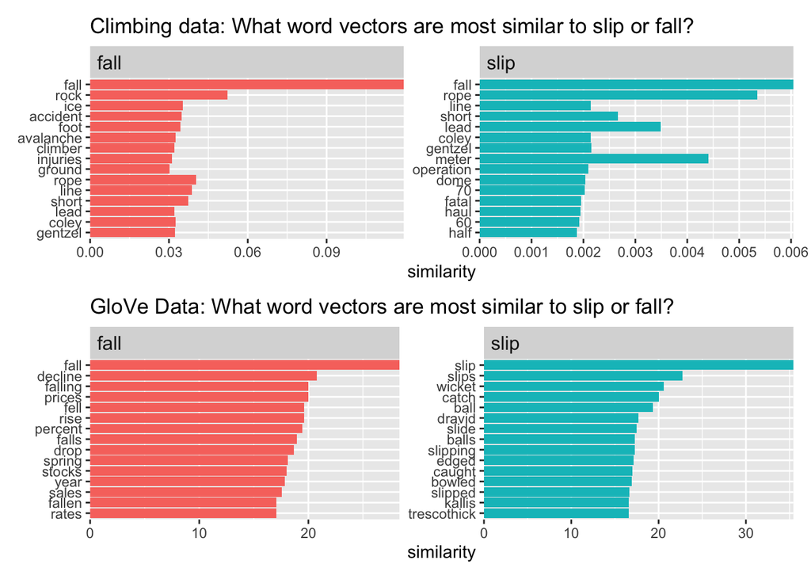

```r
glovedata_plot <- slip_2 %>%
    mutate(selected = "slip") %>%
    bind_rows(fall_2 %>%
                  mutate(selected = "fall")) %>%
    group_by(selected) %>%
    top_n(15, similarity) %>%
    ungroup %>%
    mutate(token = reorder(token, similarity)) %>%
    ggplot(aes(token, similarity, fill = selected)) +
    geom_col(show.legend = FALSE) +
    facet_wrap(~selected, scales = "free") +
    coord_flip() +
    theme(strip.text=element_text(hjust=0, size=12)) +
    scale_y_continuous(expand = c(0,0)) +
    labs(x = NULL, title = "GloVe Data: What word vectors are most similar to slip or fall?")

climbdata_plot / glovedata_plot
```

The climbing data slip and fall histograms show that the word vectors caught climbing related terms such as accident, rope and line. The GloVe data shows economic-related terms(prices, stocks, rates) for fall and cricket-related terms/players (Dravid, wicket, edged) for slip because slip is common fielding position in cricket. This is due to the GloVe data being more expansive than just climbing.

```r
snow_danger <- data_glove["snow",] + data_glove["danger",]
search_synonyms(data_glove, snow_danger)
```

```
## # A tibble: 400,000 × 2
##    token      similarity
##    <chr>           <dbl>
##  1 snow             57.6
##  2 rain             40.6
##  3 danger           40.5
##  4 snowfall         34.8
##  5 weather          34.4
##  6 winds            34.0
##  7 rains            34.0
##  8 fog              33.6
##  9 landslides       33.3
## 10 threat           33.0
## # … with 399,990 more rows
```

```r
no_snow_danger <- data_glove["danger",] - data_glove["snow",]
search_synonyms(data_glove, no_snow_danger)
```

```
## # A tibble: 400,000 × 2
##    token        similarity
##    <chr>             <dbl>
##  1 danger             23.3
##  2 risks              20.2
##  3 imminent           18.7
##  4 dangers            17.9
##  5 risk               17.8
##  6 32-team            17.6
##  7 mesdaq             17.5
##  8 inflationary       17.4
##  9 risking            17.2
## 10 2001-2011          17.0
## # … with 399,990 more rows
```

2. Run the classic word math equation, “king” - “man” = ?

```r
king_man <- data_glove["king",] - data_glove["man",]
search_synonyms(data_glove, king_man)
```

```
## # A tibble: 400,000 × 2
##    token       similarity
##    <chr>            <dbl>
##  1 king              35.3
##  2 kalākaua          26.8
##  3 adulyadej         26.3
##  4 bhumibol          25.9
##  5 ehrenkrantz       25.5
##  6 gyanendra         25.2
##  7 birendra          25.2
##  8 sigismund         25.1
##  9 letsie            24.7
## 10 mswati            24.0
## # … with 399,990 more rows
```

3. Think of three new word math equations. They can involve any words you’d like, whatever catches your interest.

```r
batman_superman <- data_glove["batman",] + data_glove["superman",]
search_synonyms(data_glove, batman_superman)
```

```
## # A tibble: 400,000 × 2
##    token      similarity
##    <chr>           <dbl>
##  1 batman           81.5
##  2 superman         79.8
##  3 spider-man       57.5
##  4 superhero        55.9
##  5 superboy         50.9
##  6 marvel           50.6
##  7 comics           48.6
##  8 x-men            48.0
##  9 supergirl        46.8
## 10 luthor           45.6
## # … with 399,990 more rows
```

```r
cricket_baseball <- data_glove["cricket",] - data_glove["baseball",]
search_synonyms(data_glove, cricket_baseball)
```

```
## # A tibble: 400,000 × 2
##    token      similarity
##    <chr>           <dbl>
##  1 cricket          38.5
##  2 wicket           28.8
##  3 indies           28.6
##  4 lanka            28.2
##  5 sri              28.0
##  6 overs            28.0
##  7 marylebone       27.9
##  8 list-a           27.8
##  9 waca             27.6
## 10 wickets          27.5
## # … with 399,990 more rows
```

```r
air_water <- data_glove["air",] - data_glove["water",]
search_synonyms(data_glove, air_water)
```

```
## # A tibble: 400,000 × 2
##    token   similarity
##    <chr>        <dbl>
##  1 air           32.5
##  2 dyess         24.3
##  3 nhut          24.0
##  4 usaf          23.6
##  5 afb           23.6
##  6 macdill       23.3
##  7 aviano        23.0
##  8 f-16          22.6
##  9 norad         22.5
## 10 raaf          22.5
## # … with 399,990 more rows
```